# Decomposing Co-Movements in Matrix-Valued Time Series

A Pseudo-Structural Reduced Rank Approach

Ivan Ricardo

Maastricht University

Alain Hecq

Maastricht University

Ines Wilms

Maastricht University

October 22, 2026

## Thirty-Six Series

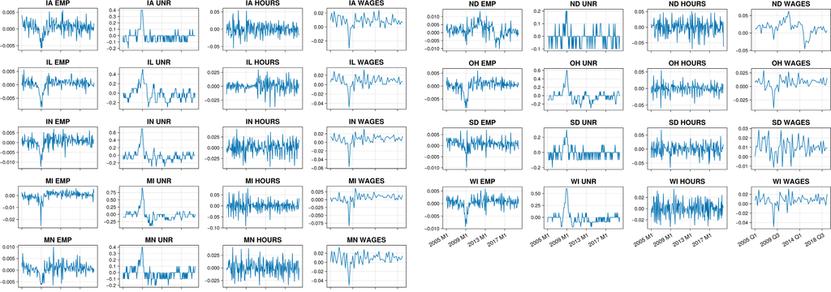

- Nine Midwestern states, four labor-market indicators, monthly changes, 2005 to 2019
- Do $36$ series need $36$ separate dynamics?

Source: Hecq et al. (2026)

## The Question in One Line

We observe $\mathbf{Y}_1, \dots, \mathbf{Y}_T \in \mathbb{R}^{N_1 \times N_2}$ and stack $\mathbf{y}_t = \operatorname{vec}(\mathbf{Y}_t)$.

Which combinations $\boldsymbol{\Psi}\mathbf{y}_t$ **lose a feature** that every series has?

The feature today:

- **Serial correlation.** $\boldsymbol{\Psi}\mathbf{y}_t$ is unpredictable: a common stationary cycle

The answer to this is the **null space**, namely, $\boldsymbol{\Psi} = \mathbf{A}_\perp'$.

# Common Cycles: The Left Null Space

## A Reduced-Rank VAR

The reduced-rank VAR($1$) (Velu et al. 1986):
$$\mathbf{y}_t = \mathbf{A}\mathbf{B}'\mathbf{y}_{t-1} + \mathbf{e}_t, \qquad \mathbf{A}, \mathbf{B} \in \mathbb{R}^{N\times r}, \quad r < N$$

Rank $r$ gives two null spaces, each of dimension $N - r$:

- **left**, $\mathbf{A}_\perp'\mathbf{A} = \mathbf{0}$: then $\mathbf{A}_\perp'\mathbf{y}_t = \mathbf{A}_\perp'\mathbf{e}_t$ is **white noise**
- **right**, $\mathbf{B}'\mathbf{B}_\perp = \mathbf{0}$: then $\mathbf{B}_\perp'\mathbf{y}_{t-1}$ predicts nothing

**Definition (Engle and Kozicki, 1993)**

A feature is **common** if every series has it but some linear combination does not. With serial correlation as the feature, $\mathbf{A}_\perp$ gives a **common cycle** (SCCF).

## A Common Cycle, by Eye

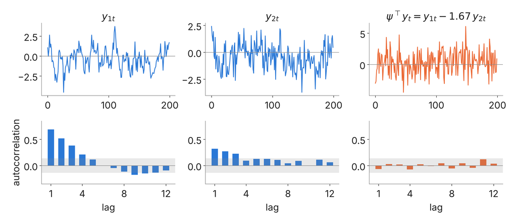

**The recurring lesson**

A co-movement is a **null space**: the combinations that remove a feature every series has. Name the feature first.

## Normalize and Stack

Normalize $\mathbf{A}_\perp' = [\,\mathbf{I}_{N-r} \mathbf{A}_\perp^{*'}]$ and stack (Vahid and Engle 1993):
$$\underbrace{\begin{bmatrix}\mathbf{I}_{N-r} & \mathbf{A}_\perp^{*'} \\ \mathbf{0} & \mathbf{I}_r\end{bmatrix}}_{\boldsymbol{\Omega}}\begin{bmatrix}\mathbf{y}_{1t} \\ \mathbf{y}_{2t}\end{bmatrix} = \begin{bmatrix}\mathbf{0} & \mathbf{0} \\ \boldsymbol{\Pi}_1^* & \boldsymbol{\Pi}_2^*\end{bmatrix}\begin{bmatrix}\mathbf{y}_{1,t-1} \\ \mathbf{y}_{2,t-1}\end{bmatrix} + \boldsymbol{\Omega}\mathbf{e}_t$$

- $N - r$ equations with **no lags**: contemporaneous relations
- $r$ equations with **all lags**: the lags act as instruments
- Same parameter count as the reduced-rank VAR, $r(2N - r)$

The **pseudo-structural form**: an equivalent rewriting, not a causal model.

## Trivial Features

If $\mathbf{y}_{1t}$ is already white noise, $\mathbf{A}_\perp = \mathbf{e}_1$ removes nothing.

- Under the normalization, a trivial feature is $\mathbf{A}_\perp^* = \mathbf{0}$
- So **test** $H_0 : \mathbf{A}_\perp^* = \mathbf{0}$, rather than exclude it from the parameter space
- To determine how many features, the $N - r$ smallest canonical correlations between $\mathbf{y}_t$ and its past are zero (Vahid and Engle 1993)

# Indices: the Right Null Space

## Read the Same Matrix from the Right

$\mathbf{A}\mathbf{B}'\mathbf{B}_\perp = \mathbf{0}$: the past in the directions $\mathbf{B}_\perp$ is **irrelevant**. So
$$\mathbf{y}_t = \mathbf{A}\,\mathbf{f}_{t-1} + \mathbf{e}_t, \qquad \mathbf{f}_{t-1} = \mathbf{B}'\mathbf{y}_{t-1} \in \mathbb{R}^r.$$

The past enters through $r$ **indices**, yielding the multivariate autoregressive index model (Reinsel 1983).

|  | left null space $\mathbf{A}_\perp$ | right null space $\mathbf{B}_\perp$ |
| --- | --- | --- |
| removes | the dynamics in $\mathbf{y}_t$ | lags without predictive content |
| result | $\mathbf{A}_\perp'\mathbf{y}_t$ is white noise | $\mathbf{B}_\perp'\mathbf{y}_{t-1}$ can be dropped |
| reading | common cycles | common predictors |

## With $p$ Lags They Part Ways

For $\mathbf{y}_t = \sum_{j=1}^{p}\mathbf{C}_j\mathbf{y}_{t-j} + \mathbf{e}_t$,

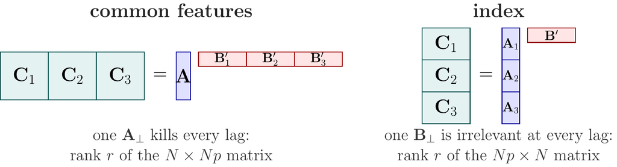

Both have $Nr(p + 1) - r^2$ parameters. Different models: one restricts what **responds**, the other what **predicts**.

## Indices and Factors

- $\mathbf{y}_t = \sum_{j=1}^p\mathbf{A}_j\mathbf{f}_{t-j} + \mathbf{e}_t$ is a factor model whose factor is **observed**: a linear combination of the past (Carriero et al. 2016; Cubadda and Guardabascio 2019)
- In a factor model $\mathbf{y}_t = \boldsymbol{\Lambda}\mathbf{f}_t + \boldsymbol{\varepsilon}_t$, the combinations $\boldsymbol{\Lambda}_\perp'\mathbf{y}_t$ are free of the factor: the left null space again
- The matrix factor model $\mathbf{Y}_t = \mathbf{R}\mathbf{F}_t\mathbf{C}' + \mathbf{E}_t$ (Wang et al. 2019) loads a latent $\mathbf{F}_t$ on rows and on columns

The matrix index on the next slides has exactly this shape, with $\mathbf{F}_t$ replaced by a **bilinear function of $\mathbf{Y}_{t-1}$**.

# Reduced-Rank Matrix Autoregressions

## The RRMAR

The matrix autoregression (Chen et al. 2021) with reduced-rank coefficients (Xiao et al., forthcoming):
$$\mathbf{Y}_t = \mathbf{U}_1\mathbf{U}_3'\,\mathbf{Y}_{t-1}\,\mathbf{U}_4\mathbf{U}_2' + \mathbf{E}_t$$
$$\mathbf{y}_t = (\mathbf{U}_2\otimes\mathbf{U}_1)(\mathbf{U}_4\otimes\mathbf{U}_3)'\mathbf{y}_{t-1} + \mathbf{e}_t, \qquad \operatorname{Cov}(\mathbf{e}_t) = \boldsymbol{\Sigma}_2\otimes\boldsymbol{\Sigma}_1$$
with $\mathbf{U}_1, \mathbf{U}_3 \in \mathbb{R}^{N_1\times r_1}$ and $\mathbf{U}_2, \mathbf{U}_4 \in \mathbb{R}^{N_2\times r_2}$

A reduced-rank VAR of rank $r_1 r_2$, with Kronecker loadings **and** weights.

**Parsimony**

$2r_1N_1 - r_1^2 + 2r_2N_2 - r_2^2$ coefficients: $39$ for $9 \times 4$ at ranks $(2,1)$, against $1{,}296$ for a VAR($1$).

## Two Readings, Again

**From the right.** $\mathbf{F}_{t-1} = \mathbf{U}_3'\mathbf{Y}_{t-1}\mathbf{U}_4 \in \mathbb{R}^{r_1\times r_2}$ is a matrix of indices,
$$\mathbf{Y}_t = \mathbf{U}_1\,\mathbf{F}_{t-1}\,\mathbf{U}_2' + \mathbf{E}_t,$$
a matrix factor model with a factor we can **compute**.

**From the left.** Take $\boldsymbol{\delta} \in \mathbb{R}^{N_1\times(N_1-r_1)}$ and $\boldsymbol{\gamma} \in \mathbb{R}^{N_2\times(N_2-r_2)}$ with $\boldsymbol{\delta}'\mathbf{U}_1 = \mathbf{0}$ and $\boldsymbol{\gamma}'\mathbf{U}_2 = \mathbf{0}$:
$$\boldsymbol{\delta}'\mathbf{Y}_t = \boldsymbol{\delta}'\mathbf{E}_t, \qquad \mathbf{Y}_t\boldsymbol{\gamma} = \mathbf{E}_t\boldsymbol{\gamma}.$$

$\boldsymbol{\delta}$: rows that co-move **in every column**. $\boldsymbol{\gamma}$: columns that co-move **in every row**.

## Proposition 1

**Proposition 1 (Hecq, Ricardo and Wilms, 2026)**

With $\boldsymbol{\delta}'\mathbf{U}_1 = \mathbf{0}$ and $\boldsymbol{\gamma}'\mathbf{U}_2 = \mathbf{0}$, the left null space of $\mathbf{U}_2\otimes\mathbf{U}_1$, of dimension $N_1N_2 - r_1r_2$, is the orthogonal direct sum of three Kronecker pieces ($\mathcal{C}$: column space, $\mathcal{N}$: null space):

$$\mathcal{N}\big((\mathbf{U}_2\otimes\mathbf{U}_1)'\big) = \underbrace{\big(\mathcal{N}(\mathbf{U}_2')\otimes\mathcal{C}(\mathbf{U}_1)\big)}_{\text{column-specific}} \oplus \underbrace{\big(\mathcal{C}(\mathbf{U}_2)\otimes\mathcal{N}(\mathbf{U}_1')\big)}_{\text{row-specific}} \oplus \underbrace{\big(\mathcal{N}(\mathbf{U}_2')\otimes\mathcal{N}(\mathbf{U}_1')\big)}_{\text{joint}}$$

$\boldsymbol{\delta}'\mathbf{Y}_t$ and $\mathbf{Y}_t\boldsymbol{\gamma}$ **overlap** in $\boldsymbol{\delta}'\mathbf{Y}_t\boldsymbol{\gamma}$: that overlap is the joint piece. Row- and column-specific are what is left of each once it is removed.

Proof

Hecq et al. (2026)

## Four Boxes

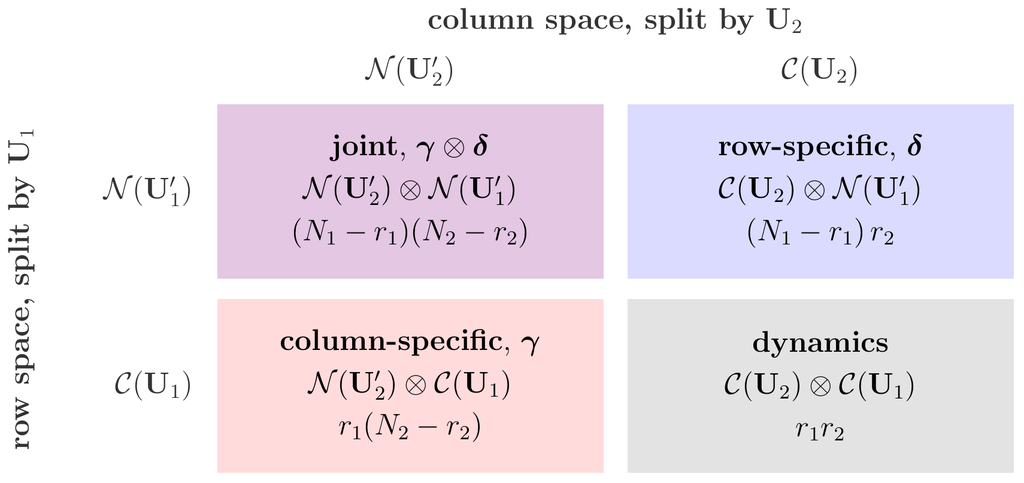

Only the bottom-right box sees $\mathbf{y}_{t-1}$. The other three are white noise.

## A Toy Example

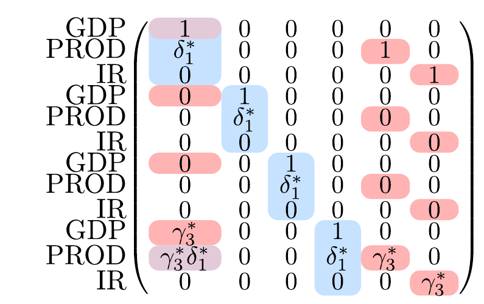

GDP, PROD, IR $\times$ USA, CAN, DEU, FRA, at ranks $(2, 3)$

- Row-specific, $\boldsymbol{\delta}$: GDP with PROD, in every country
- Column-specific, $\boldsymbol{\gamma}$: USA with France, for every indicator
- Joint, $\boldsymbol{\gamma}\otimes\boldsymbol{\delta}$: US GDP with US PROD, French GDP and French PROD **at once**

## The Pseudo-Structural Form

Normalize $\boldsymbol{\delta}' = [\,\mathbf{I}\;\; \boldsymbol{\delta}^{*\top}]$ and $\boldsymbol{\gamma}' = [\,\mathbf{I}\;\; \boldsymbol{\gamma}^{*\top}]$, and build $\boldsymbol{\Omega}_1$ and $\boldsymbol{\Omega}_2$ as in the vector case:
$$\boldsymbol{\Omega}_1\mathbf{Y}_t\boldsymbol{\Omega}_2' = \begin{bmatrix}\mathbf{0} & \mathbf{0} \\ \mathbf{0} & \mathbf{U}_3^{*\top}\mathbf{Y}_{t-1}\mathbf{U}_4^*\end{bmatrix} + \boldsymbol{\Omega}_1\mathbf{E}_t\boldsymbol{\Omega}_2'$$

with left-hand side
$$\begin{bmatrix}\mathbf{Y}_{11,t} + \boldsymbol{\delta}^{*\top}\mathbf{Y}_{21,t} + \mathbf{Y}_{12,t}\boldsymbol{\gamma}^* + \boldsymbol{\delta}^{*\top}\mathbf{Y}_{22,t}\boldsymbol{\gamma}^* & \mathbf{Y}_{12,t} + \boldsymbol{\delta}^{*\top}\mathbf{Y}_{22,t} \\ \mathbf{Y}_{21,t} + \mathbf{Y}_{22,t}\boldsymbol{\gamma}^* & \mathbf{Y}_{22,t}\end{bmatrix}$$

Three blocks are the boxes of Proposition 1. The fourth carries **all** the lags.

Vectorized form

## Who Responds to Whom

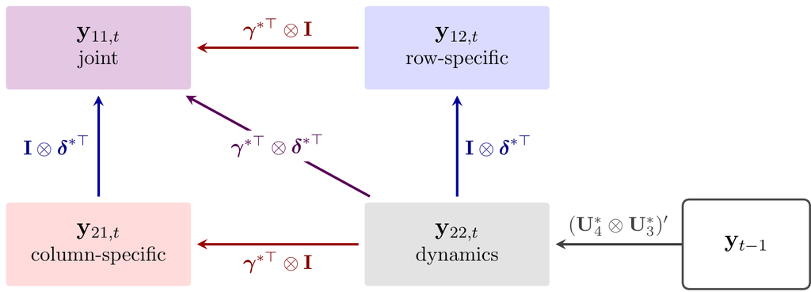

- Vertical arrows are $\boldsymbol{\delta}^*$, horizontal arrows $\boldsymbol{\gamma}^*$, the diagonal is their Kronecker product
- Which $r_1$ rows and $r_2$ columns form $\mathbf{Y}_{22}$ does not change the likelihood. It changes the **story**, so choose by economics

## Estimation and Ranks

- **Full-information ML**, non-convex: $100$ random starts, a few iterations each, continue the best $10$
- A single start at the RRMAR estimate ends in a **local optimum** in a third of the $\boldsymbol{\delta}^*$ simulations
- $\widehat{\boldsymbol{\delta}}^*$, $\widehat{\boldsymbol{\gamma}}^*$: $\sqrt{T}$-asymptotically normal, Hessian standard errors
- **Ranks** and lag order by BIC or EBIC, both weakly consistent

Rank selection

## Coverage When the Ranks Are Wrong

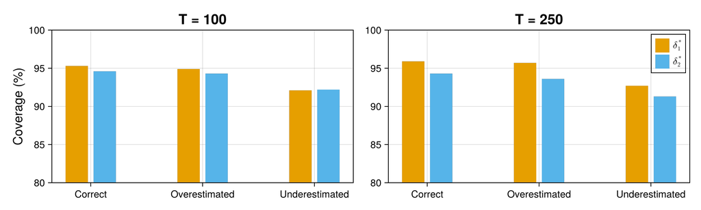

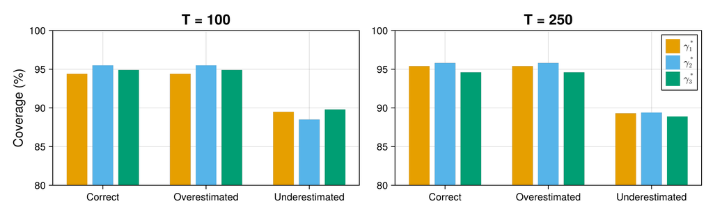

**Over beats under.** If unsure about $r_1$, set it to $N_1$ and select $r_2$.

## Midwestern Labor Markets

- $9$ states $\times$ $4$ indicators: employment, unemployment rate, manufacturing hours, real wages. January 2005 to December 2019, $T = 180$, first differences, demeaned
- Ranks: AIC $(8,4)$, BIC $(5,4)$, EBIC $(2,1)$. We adopt EBIC: best in the simulations, and one common component in the indicators is what a **coincident index** needs
- The RRMAR beats the reduced-rank VAR and the unrestricted VAR on BIC and EBIC. AIC prefers the reduced-rank VAR
- $\mathbf{Y}_{22}$: **Iowa** and **Ohio** (agriculture and manufacturing, far apart) and **wages** (the slowest-moving indicator)

## What the Co-Movements Say

$\widehat{\boldsymbol{\gamma}}^*$, indicators relative to wages ($p$-values in parentheses):

| $\Delta$Employment | $\Delta$Unemployment | $\Delta$Hours |
| --- | --- | --- |
| $\mathbf{-0.63}$ $(0.00)$ | $\mathbf{70.58}$ $(0.00)$ | $-0.16$ $(0.74)$ |

$\widehat{\boldsymbol{\delta}}^*$, states relative to the two anchors (bold: significant at $5\%$):

|  | ND | IN | MI | MN | IL | SD | WI |
| --- | --- | --- | --- | --- | --- | --- | --- |
| Ohio | $-0.29$ | $-0.26$ | $-0.58$ | $-0.18$ | $\mathbf{-2.48}$ | $0.06$ | $-0.07$ |
| Iowa | $-0.02$ | $\mathbf{-1.39}$ | $\mathbf{-1.38}$ | $\mathbf{-0.75}$ | $\mathbf{2.46}$ | $\mathbf{-0.76}$ | $\mathbf{-1.47}$ |

Iowa’s cycle reaches most of the region, Ohio’s reaches Illinois. North Dakota stands apart.

## Against a Benchmark

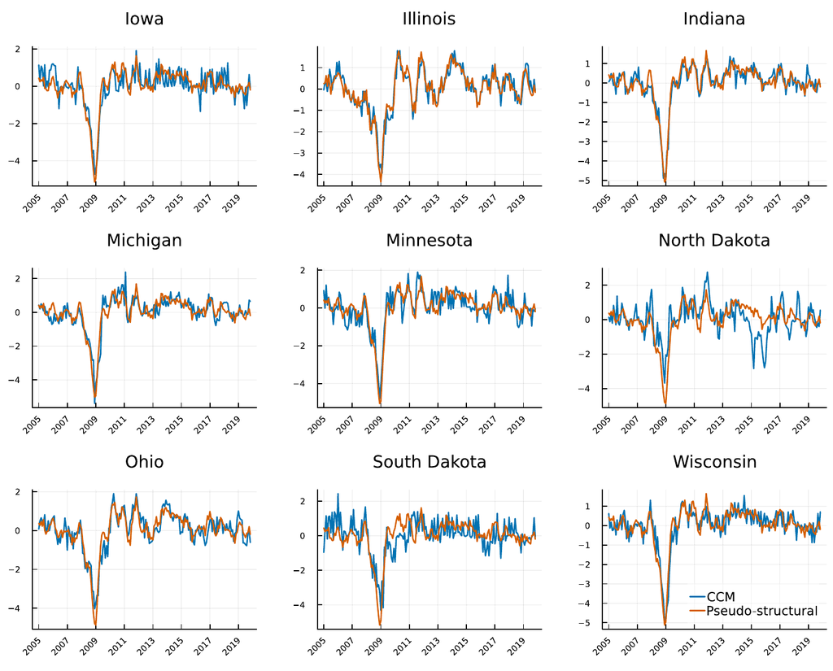

Correlation with the index of Crone and Clayton-Matthews: $0.85$ to $0.94$ in seven states, $0.59$ in North Dakota, $0.68$ in South Dakota.

Crone and Clayton-Matthews (2005)

## We Differenced

Employment, hours and wages are $I(1)$ in (log) levels. We modeled $\Delta\mathbf{Y}_t$.

If the levels are **cointegrated**, a VAR in differences leaves out the error-correction term.

Next: keep the levels, and ask which combinations are **stationary**.

# Conclusion

## Taking Stock

- Two null spaces: the left gives **common cycles**, the right **indices**. With $p$ lags, two different models
- Row and column restrictions give **three** co-movement components, each with its own pseudo-structural block

**The recurring lesson**

A co-movement is a **null space**: the combinations that remove a feature every series has. Name the feature first.

## References

Carriero, Andrea, George Kapetanios, and Massimiliano Marcellino. 2016. “Structural Analysis with Multivariate Autoregressive Index Models.” *Journal of Econometrics* 192 (2): 332–48.

Chen, Rong, Han Xiao, and Dan Yang. 2021. “Autoregressive Models for Matrix-Valued Time Series.” *Journal of Econometrics* 222 (1): 539–60.

Crone, Theodore M., and Alan Clayton-Matthews. 2005. “Consistent Economic Indexes for the 50 States.” *Review of Economics and Statistics* 87 (4): 593–603.

Cubadda, Gianluca, and Barbara Guardabascio. 2019. “Representation, Estimation and Forecasting of the Multivariate Index-Augmented Autoregressive Model.” *International Journal of Forecasting* 35 (1): 67–79.

Engle, Robert F., and Sharon Kozicki. 1993. “Testing for Common Features.” *Journal of Business & Economic Statistics* 11 (4): 369–80.

Hecq, Alain, Ivan Ricardo, and Ines Wilms. 2026. “Decomposing Co-Movements in Matrix-Valued Time Series: A Pseudo-Structural Reduced Rank Approach.” *Econometrics and Statistics*, ahead of print. https://doi.org/10.1016/j.ecosta.2026.07.002.

Reinsel, Gregory C. 1983. “Some Results on Multivariate Autoregressive Index Models.” *Biometrika* 70 (1): 145–56.

Vahid, Farshid, and Robert F. Engle. 1993. “Common Trends and Common Cycles.” *Journal of Applied Econometrics* 8 (4): 341–60.

Velu, Raja P., Gregory C. Reinsel, and Dean W. Wichern. 1986. “Reduced Rank Models for Multiple Time Series.” *Biometrika* 73 (1): 105–18.

Wang, Dong, Xialu Liu, and Rong Chen. 2019. “Factor Models for Matrix-Valued High-Dimensional Time Series.” *Journal of Econometrics* 208 (1): 231–48.

Xiao, Han, Yuefeng Han, Rong Chen, and Chengcheng Liu. Forthcoming. “Reduced Rank Autoregressive Models for Matrix Time Series.” *Journal of Business & Economic Statistics*.

# Appendix

## The Balanced System

- $\mathbf{y}_{11,t}$: joint, depends on $\mathbf{y}_{21,t}$, $\mathbf{y}_{12,t}$ and $\mathbf{y}_{22,t}$
- $\mathbf{y}_{21,t}$ and $\mathbf{y}_{12,t}$: column- and row-specific, depend on $\mathbf{y}_{22,t}$
- $\mathbf{y}_{22,t}$: the only block with lags
- $\det\boldsymbol{\Omega} = 1$, and the parameter count equals the RRMAR’s

Back to main

## Rank Selection in Simulations

$N_1\times N_2 = 3\times 4$, lag order fixed at one, $T = 100$, percentage of correct selections for $(r_1, r_2)$:

| true ranks | AIC | BIC | EBIC | Xiao et al. |
| --- | --- | --- | --- | --- |
| $(1,1)$ | $(89, 81)$ | $(100, 99)$ | $(100, 99)$ | $(98, 98)$ |
| $(2,1)$ | $(80, 83)$ | $(94, 100)$ | $(100, 100)$ | $(98, 99)$ |
| $(3,1)$ | $(100, 85)$ | $(100, 100)$ | $(100, 100)$ | $(100, 100)$ |
| $(1,4)$ | $(87, 100)$ | $(100, 100)$ | $(100, 100)$ | $(100, 100)$ |

- With the lag chosen jointly, true $(1,1)$ and $p = 1$: right lag $8\%$ (AIC), $90\%$ (BIC), $100\%$ (EBIC)
- Application size ($9\times 4$, $T = 180$, ranks $(2,1)$): BIC, EBIC, benchmark above $91\%$

Back to main

## The Rearrangement

Cut $\mathbf{M}$ into $N_1\times N_1$ blocks and line up their vectorizations as columns. For $\mathbf{M} = \mathbf{B}\otimes\mathbf{A}$ with $N_2 = 2$ and $\mathbf{a} = \operatorname{vec}(\mathbf{A})$:
$$\begin{bmatrix} b_{11}\mathbf{A} & b_{12}\mathbf{A} \\ b_{21}\mathbf{A} & b_{22}\mathbf{A}\end{bmatrix}
\;\overset{\mathcal{R}}{\longmapsto}\;
\big[\, b_{11}\mathbf{a} \;\; b_{21}\mathbf{a} \;\; b_{12}\mathbf{a} \;\; b_{22}\mathbf{a} \,\big]
= \mathbf{a}\operatorname{vec}(\mathbf{B})'$$

$\mathcal{R}$ only permutes entries, so it is linear, and $\mathbf{M}$ is a Kronecker product if and only if $\mathcal{R}(\mathbf{M})$ has rank one.

For a sum, $\operatorname{rank}(\mathbf{a}\mathbf{b}' + \mathbf{c}\mathbf{d}') \le 1$ only if $\mathbf{a}\parallel\mathbf{c}$ or $\mathbf{b}\parallel\mathbf{d}$. With $\mathbf{c} = \operatorname{vec}(\mathbf{I})$, that means $\boldsymbol{\Lambda}\propto\mathbf{I}$ or $\boldsymbol{\Psi}\propto\mathbf{I}$ for the C-MAR, and $\mathbf{U}_1\mathbf{U}_3'\propto\mathbf{I}$ or $\mathbf{U}_2\mathbf{U}_4'\propto\mathbf{I}$ for the MECM. Reduced rank rules out both.

Back to main